# Chicken Tikka Masala

| Tags | Indian |
| --- | --- |
| Estimate Time | 1-2 |
| Cost | $ |

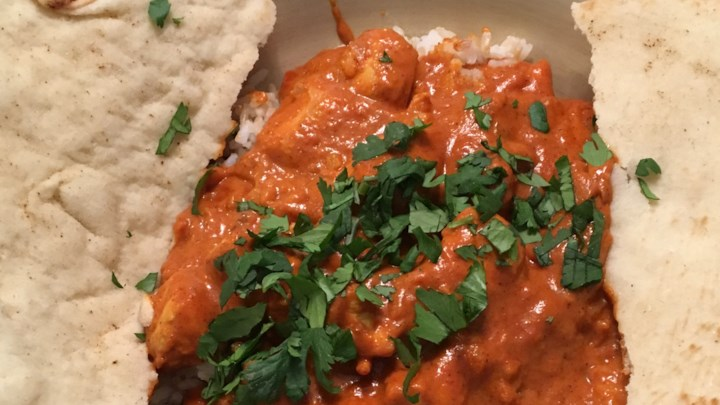

## Ingredients

SAUCE

1 finely chopped onion

4 cloves garlic

1 tsp ground ginger

1 T cumin

1 tsp salt

1 tsp cayenne

1/2 tsp cinnamon

1/4 tsp turmeric

14 oz tomato sauce

2 T butter

1 c. heavy whipping cream

2 tsp paprika

CHICKEN

2 skinless boneless chicken breast or thighs

1/2 tsp curry powder

optional - broccoli, carrots, peas, beans, potatoes

## Directions

Heat butter in a large pot over medium heat and cook and stir onion until translucent, about 5 minutes. Stir in garlic; cook and stir just until fragrant, about 1 minute. Stir cumin, 1 teaspoon salt, ginger, cayenne pepper, cinnamon, and turmeric into the onion mixture; fry until fragrant, about 2 minutes.

Stir tomato sauce into the onion and spice mixture, bring to a boil, and reduce heat to low. Simmer sauce for 10 minutes, then mix in cream, paprika. Bring sauce back to a simmer and cook, stirring often, until sauce is thickened, 10 to 15 minutes.

Meanwhile, brown diced chicken and then sprinkle curry powder. Transfer to veggies and let simmer until cooked through.